# Analysis Report for Mass Spectrometry Data

Siwen Chen

2024-03-18

# 1 Task description

**Data**

- A tsv file (“Protein_abundance.tsv”) - protein abundance measured by label-free mass-spectrometry for chronic lymphocytic leukemia (CLL) patient samples
- An excel table (“sampleAnnotation.xls”) - some basic annotations for those samples

**Task**

- process the protein abundance dataset
- assess its quality
- identify protein markers for prognosis

# 2 Data Preprocessing

## 2.1 List packages used

```r
library(DOSE)
library(enrichplot)
library(clusterProfiler)
library(factoextra)
library(FactoMineR)
library(DEP)
library(stringr)
library(tidyr)
library(dplyr)
library(SummarizedExperiment)
library(readxl)
library(caret)
library(UniProt.ws)
library(ggplot2)
```

## 2.2 Data Inspection - Raw protein abundance data

```r
prot_abundance <- read.table(file = "Protein_abundance.tsv", sep = "\t", header = TRUE)

# Sort the columns of the data frame numerically
prot_abundance <- prot_abundance[, c("X1", str_sort(colnames(prot_abundance[,-1]), numeric = TRUE))]

# Set "X1" column as row index
rownames(prot_abundance) <- prot_abundance$X1
prot_abundance <- prot_abundance[, 2:ncol(prot_abundance)]

head(prot_abundance, 2)
```

```
#>                              A_1_1    A_1_2     A_1_3     A_1_4    A_1_5
#> sp|A0A0B4J2F0|PIOS1_HUMAN  52102.1  44425.1  62139.94  49757.98 114634.0
#> sp|A0A0U1RRE5|NBDY_HUMAN  360139.2 229613.9 786485.10 703263.53 196684.9
#>                               A_1_6     A_1_7     A_1_8     A_1_9   A_1_10
#> sp|A0A0B4J2F0|PIOS1_HUMAN  80361.08  65810.94  42605.01  99264.02 125050.9
#> sp|A0A0U1RRE5|NBDY_HUMAN  589261.75 661849.80 692631.30 360189.13 753984.2
#>                             A_1_11    A_1_12   A_1_13    A_1_14   A_1_15
#> sp|A0A0B4J2F0|PIOS1_HUMAN 127950.7  53948.97 107912.8  77528.14 108104.1
#> sp|A0A0U1RRE5|NBDY_HUMAN  447030.5 731422.23 684069.3 648198.63 438458.7
#>                             A_1_16   A_1_17   A_1_18    A_1_19    A_1_20
#> sp|A0A0B4J2F0|PIOS1_HUMAN  52705.0 131094.0 111673.9  23909.99  35395.98
#> sp|A0A0U1RRE5|NBDY_HUMAN  660127.2 687005.1 727560.7 471053.99 287915.10
#>                              A_1_21    A_1_22    A_1_23    A_1_24   A_1_25
#> sp|A0A0B4J2F0|PIOS1_HUMAN  19954.95  78414.95  52341.95  54708.03 116855.9
#> sp|A0A0U1RRE5|NBDY_HUMAN  381103.09 177628.96 305856.57 252826.23 825257.9
#>                             A_1_26   A_1_27    A_1_28    A_1_29   A_1_30
#> sp|A0A0B4J2F0|PIOS1_HUMAN  82719.1 160444.3  63658.08  93193.02 228753.9
#> sp|A0A0U1RRE5|NBDY_HUMAN  867045.8 786750.6 196027.44 677105.60 227133.2
#>                             A_1_31   A_1_32    A_1_33   A_1_34   A_1_35
#> sp|A0A0B4J2F0|PIOS1_HUMAN 441517.5 109222.1  84577.89 252492.1 416634.0
#> sp|A0A0U1RRE5|NBDY_HUMAN  873536.0 387875.3 678207.60 473262.2 590923.9
#>                              A_1_36    A_1_37    A_1_38    A_1_39   A_1_40
#> sp|A0A0B4J2F0|PIOS1_HUMAN  40899.06  80713.99  61618.99  74648.01  90395.9
#> sp|A0A0U1RRE5|NBDY_HUMAN  154202.50 294530.28 722931.90 785166.20 284436.2
#>                              A_1_41    A_1_42    A_1_43    A_1_44    A_1_45
#> sp|A0A0B4J2F0|PIOS1_HUMAN  65235.05  54903.02  64876.91  84974.09  63600.95
#> sp|A0A0U1RRE5|NBDY_HUMAN  559895.53 258065.87 677109.60 539836.57 305968.06
#>                              A_1_46   A_1_47   A_1_48    A_1_49
#> sp|A0A0B4J2F0|PIOS1_HUMAN  94610.98 128579.2 148041.1  98653.94
#> sp|A0A0U1RRE5|NBDY_HUMAN  697089.00 579907.9 759759.9 686380.40
```

## 2.3 Data Inspection - Sample Annotation Data

```r
annotation <- as.data.frame(read_excel("sampleAnnotation.xls"))
names(annotation)[names(annotation) == 'total protein concentration'] <- 'total.protein.concentration'
names(annotation)[names(annotation) == 'last known alive'] <- 'last.known.alive'
names(annotation)[names(annotation) == 'date of diagnosis'] <- 'date.of.diagnosis'
rownames(annotation) <- annotation$'sample ID'

# The last sample ID in the annotation file is removed, as there is no protein abundance measurement with this sample.
annotation <- annotation[1:49, 2:ncol(annotation)]

# Convert data types
annotation$operator <- as.factor(annotation$operator)
annotation$batch <- as.factor(annotation$batch)
annotation$total.protein.concentration <- as.double(unlist(annotation$total.protein.concentration))
annotation$freeThawCycle <- as.factor(annotation$freeThawCycle)

head(annotation, 2)
```

```
#>       operator batch total.protein.concentration freeThawCycle
#> A_1_1       MG     1                    71.40233             1
#> A_1_2       MG     6                   521.99011             1
#>       date.of.diagnosis  died last.known.alive
#> A_1_1        1993-06-15 FALSE       2017-09-22
#> A_1_2        1999-06-15 FALSE       2017-06-15
```

## 2.4 Create a SummerizedExperiment object containing both data

```r
# Prepare the protein abundance data as assay data for the SE object
prot_abundance_se <- read.table(file = "Protein_abundance.tsv", sep = "\t", header = TRUE)
prot_abundance_se <- prot_abundance_se[, c("X1", str_sort(colnames(prot_abundance_se[,-1]), numeric = TRUE))]
prot_abundance_se <- separate_wider_delim(prot_abundance_se, cols = X1, delim = "|", names = c("prefix", "protID", "geneName"))
prot_abundance_se <- make_unique(prot_abundance_se, "geneName", "protID")

column_names <- grep("A_1_", colnames(prot_abundance_se))
se <- make_se_parse(prot_abundance_se, column_names, mode = "delim", sep = "-")
```

Inspection on the SummerizedExperiment object

```r
se
```

```
#> class: SummarizedExperiment
#> dim: 3942 49
#> metadata(0):
#> assays(1): ''
#> rownames(3942): PIOS1_HUMAN NBDY_HUMAN ... PLBL2_HUMAN DDX55_HUMAN
#> rowData names(5): prefix protID geneName name ID
#> colnames(49): X1_NA X2_NA ... X48_NA X49_NA
#> colData names(4): label ID condition replicate
```

Inspection on the protein abundance data enclosed in the *se* object

```r
head(assay(se))
```

```
#>                X1_NA    X2_NA    X3_NA    X4_NA    X5_NA    X6_NA    X7_NA
#> PIOS1_HUMAN 15.66905 15.43909 15.92323 15.60264 16.80668 16.29421 16.00604
#> NBDY_HUMAN  18.45820 17.80885 19.58506 19.42371 17.58553 19.16855 19.33614
#> MMPOS_HUMAN       NA       NA 15.61890 14.86878 14.44391 15.75690 15.50854
#> RBM47_HUMAN 15.62036 13.08863       NA       NA       NA       NA 15.96972
#> UBA6_HUMAN  17.21122 14.86278 17.26161 17.53653 15.32488 17.42262 17.20401
#> ESYT2_HUMAN 11.13057       NA 13.14911 12.81478 11.64565 12.28511 12.70044
#>                X8_NA    X9_NA   X10_NA   X11_NA   X12_NA   X13_NA   X14_NA
#> PIOS1_HUMAN 15.37874 16.59898 16.93216 16.96523 15.71931 16.71951 16.24243
#> NBDY_HUMAN  19.40173 18.45840 19.52417 18.77001 19.48034 19.38378 19.30608
#> MMPOS_HUMAN 15.60600 13.12137 15.96079 13.82645 14.26393 13.84226 13.79096
#> RBM47_HUMAN       NA 15.20755       NA       NA 13.90295       NA 14.91578
#> UBA6_HUMAN  17.34902 15.93277 17.54194 16.85260 17.46749 16.92984 16.77759
#> ESYT2_HUMAN 12.92907 11.95166 13.99630 12.27380 11.94690 10.33649 13.62479
#>               X15_NA   X16_NA   X17_NA   X18_NA   X19_NA   X20_NA   X21_NA
#> PIOS1_HUMAN 16.72206 15.68565 17.00024 16.76893 14.54533 15.11130 14.28446
#> NBDY_HUMAN  18.74208 19.33238 19.38996 19.47271 18.84553 18.13528 18.53982
#> MMPOS_HUMAN 13.93194 13.70919 15.25628 15.85902 14.25156 12.98477 14.39948
#> RBM47_HUMAN       NA       NA       NA       NA 15.60142 14.13755       NA
#> UBA6_HUMAN  17.03876 17.05783 16.94018 17.31317 16.34204 15.73524 16.19539
#> ESYT2_HUMAN 12.87248 11.87306 10.91440 12.39848 12.40035       NA 12.49560
#>                X22_NA   X23_NA   X24_NA   X25_NA   X26_NA   X27_NA   X28_NA
#> PIOS1_HUMAN 16.258841 15.67568 15.73946 16.83437 16.33593 17.29171 15.95806
#> NBDY_HUMAN  17.438507 18.22250 17.94779 19.65449 19.72575 19.58555 17.58070
#> MMPOS_HUMAN 11.565100 12.47294 12.12638 15.29634 16.71671 16.40221 12.38801
#> RBM47_HUMAN 16.112501 13.56128 14.19691 15.39191 16.51655 15.79652 15.25425
#> UBA6_HUMAN  15.324218 15.52736 15.75201 17.75586 17.82468 17.73499 15.37324
#> ESYT2_HUMAN  9.372842 11.12736 11.84902 11.77520 11.78012 13.00686 12.09671
#>               X29_NA   X30_NA   X31_NA   X32_NA   X33_NA   X34_NA   X35_NA
#> PIOS1_HUMAN 16.50793 17.80344 18.75211 16.73691 16.36799 17.94588 18.66842
#> NBDY_HUMAN  19.36902 17.79318 19.73651 18.56523 19.37137 18.85228 19.17261
#> MMPOS_HUMAN 15.47627 11.94544 15.84848 15.03234 16.83824 14.39512 16.03886
#> RBM47_HUMAN       NA 15.11476       NA 16.90168 17.03130       NA       NA
#> UBA6_HUMAN  17.67317 15.74084 18.06178 17.00227 17.24619 16.81648 17.36625
#> ESYT2_HUMAN 13.14895 10.74149 13.87565 12.65464 13.13732 12.79300 11.76364
#>               X36_NA   X37_NA   X38_NA   X39_NA   X40_NA   X41_NA   X42_NA
#> PIOS1_HUMAN 15.31978 16.30053 15.91109 16.18782 16.46397 15.99336 15.74460
#> NBDY_HUMAN  17.23447 18.16806 19.46350 19.58264 18.11775 19.09480 17.97738
#> MMPOS_HUMAN       NA 13.21189 16.57839 15.09602 13.49273 14.46480 13.10148
#> RBM47_HUMAN 15.35828 15.09482 16.09894 15.62933 16.31747       NA       NA
#> UBA6_HUMAN  15.84887 16.43295 17.99624 17.62260 15.97618 17.81303 16.23045
#> ESYT2_HUMAN 12.73830       NA 12.95456 13.52503 11.90237 12.17618 11.01542
#>               X43_NA   X44_NA   X45_NA   X46_NA   X47_NA   X48_NA   X49_NA
#> PIOS1_HUMAN 15.98542 16.37474 15.95676 16.52972 16.97230 17.17564 16.59009
#> NBDY_HUMAN  19.36903 19.04216 18.22302 19.41098 19.14546 19.53518 19.38865
#> MMPOS_HUMAN 15.36745 14.28887 12.65598 16.77891 14.99391 15.33365 15.25211
#> RBM47_HUMAN 16.22844 15.13955 14.80454 15.86356       NA 16.16496 16.24644
#> UBA6_HUMAN  17.56278 17.09048 16.51382 17.77657 17.12643 17.54290 17.72217
#> ESYT2_HUMAN 13.24199 12.38479 12.41390 12.88951 11.37123 12.61356 12.28396
```

# 3 TASK - Data processing

The protein abundance in the tsv file is not normalized and has missing values, which is very common in the data table you will get from a proteomic facility. You need to use a proper way to normalize the protein abundance and deal with missing values.

## 3.1 Data Normalization

The raw data is first log2-transformed when constructing the SummerizedExperiment object. This log-transformation is for better observation on fold changes between protein abundance which is more biological-relevant (like doubling), instead of additive changes. After that, the data normalization is implemented for better comparison of protein abundances among different samples and removal technical variability,

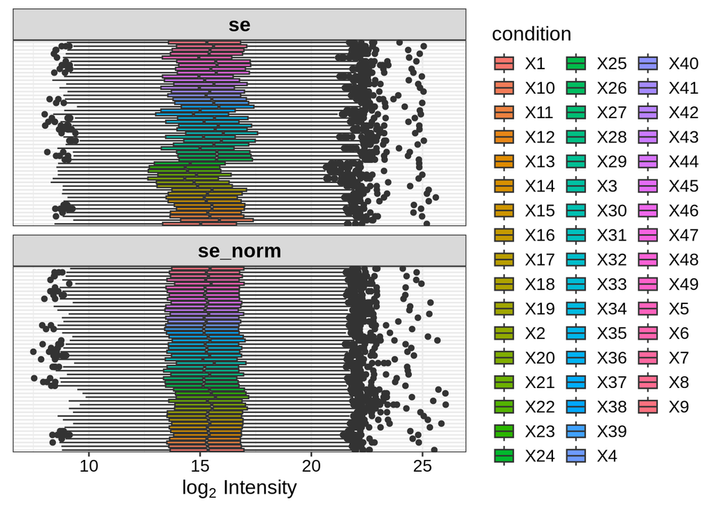

```r
se_norm <- normalize_vsn(se)
plot_normalization(se, se_norm) +
        theme(axis.title.y=element_blank(),
        axis.text.y=element_blank(),
        axis.ticks.y=element_blank())
```

After data normalization, it can be observed that the protein abundance data fall into a closer range for comparison.

## 3.2 Data Imputation

### 3.2.1 Data Visualization before Data Imputation

Plot the number of proteins overlapped among samples - The barplot shows that most proteins can be identified in all samples, as indicated in the last bar.

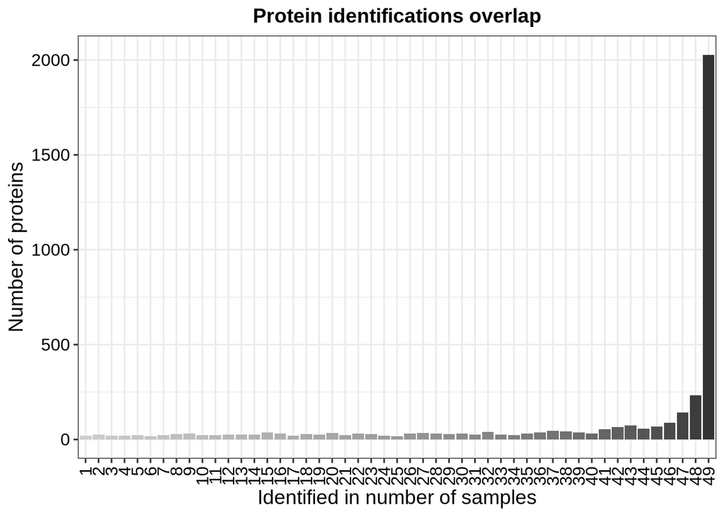

```r
plot_frequency(se)
```

The figure above displays the data missingness among samples.

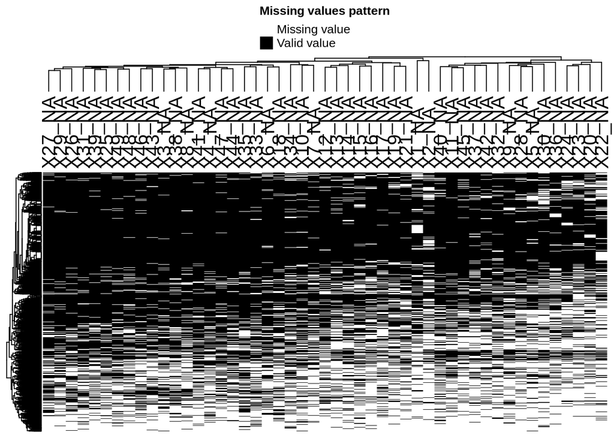

```r
plot_missval(se)
```

### 3.2.2 Data Imputation

As there is no additional information provided about the experiment design and different processing steps among samples, it is assumed that the missing values in the MS data are completly at random. Given this situation, k-Nearest Neighbor (kNN) algorithm is utilized for the protein data imputation, as it normally promises better predictions. There are also alternative imputation methods, for example, Local Least squares (LLSimpute), which was proved closer to correct data points[^1].

```r
se_imputed <- impute(se_norm, fun = "knn", k=100, rowmax = 1)
```

```
#> Cluster size 3942 broken into 1133 2809
#> Done cluster 1133
#> Cluster size 2809 broken into 1111 1698
#> Done cluster 1111
#> Cluster size 1698 broken into 1059 639
#> Done cluster 1059
#> Done cluster 639
#> Done cluster 1698
#> Done cluster 2809
```

### 3.2.3 Data Visualization after Data Imputation

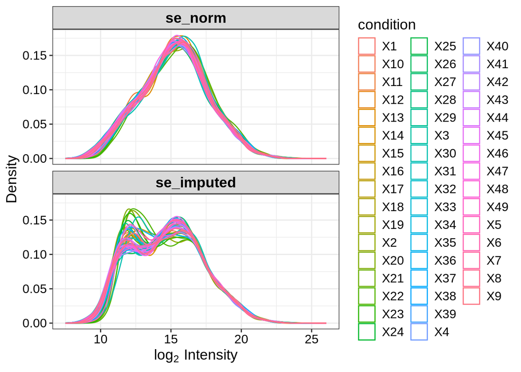

```r
plot_imputation(se_norm, se_imputed)
```

Above the imputation effect is visualized. It shows that although it appears an additional peak, it is still close to the original peak and fit the original distribution.

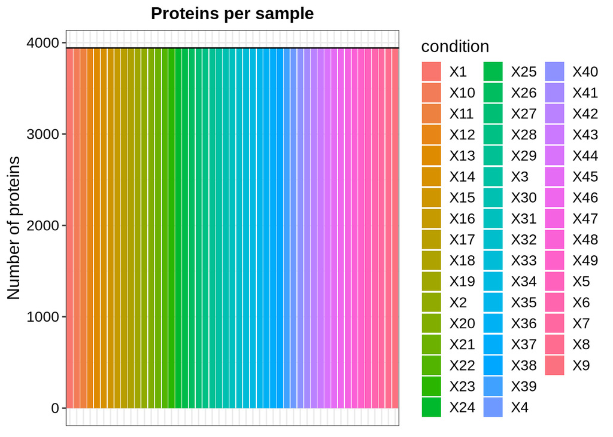

```r
plot_numbers(se_imputed) +
        theme(axis.title.x=element_blank(),
        axis.text.x=element_blank(),
        axis.ticks.x=element_blank())
```

Also, it can be observed that after data imputation, there is 0 missing data among the samples now.

# 4 TASK - Quality assessment

The protein abundance measurement can often be influenced by technical factors, such as batch effect, operators, total protein concentrations, and free thaw cycles of the cells. Those technical factors could potentially act as confounders for downstream analysis. In the sample annotation table, you will find the technical factors and you need to evaluate whether they will confound downstream analysis.

## 4.1 Multivariate Linear Regression for Confounding Factor Identification

Here the number of identified proteins in each sample is taken as the evaluation standard.

```r
# Add the number of unidentified proteins in each sample as the dependent variable to the annotation dataframe for multivariate linear regression
prot_abundance_na_count <-sapply(prot_abundance, function(y) sum(length(which(is.na(y)))))
annotation$NA_count <- prot_abundance_na_count

head(annotation, 2)
```

```
#>       operator batch total.protein.concentration freeThawCycle
#> A_1_1       MG     1                    71.40233             1
#> A_1_2       MG     6                   521.99011             1
#>       date.of.diagnosis  died last.known.alive NA_count
#> A_1_1        1993-06-15 FALSE       2017-09-22      852
#> A_1_2        1999-06-15 FALSE       2017-06-15     1018
```

The confounding effect of the technical factors are evaluated by the results from linear regression models. First, a multivariate linear regression model is built using all technival varaiables. Later on, individual univariate linear regression models are built for each potential confounding factor against the dependent variable. By comparison on the different coefficients of the potential confounding variables between the univariate and multivariate linear regression models, the confounding effect can be inferred. As a rule of thumb, if the change of the coefficient is more than 10%, this variable can be a confounding factor[^2].

### 4.1.1 Build a multivariate linear regression with all technical factors

```r
full_model <- lm(formula = NA_count ~ operator + batch + total.protein.concentration + freeThawCycle, data = annotation)
summary_full <- summary(full_model)
summary_full
```

```
#>
#> Call:
#> lm(formula = NA_count ~ operator + batch + total.protein.concentration +
#>     freeThawCycle, data = annotation)
#>
#> Residuals:
#>    Min     1Q Median     3Q    Max
#> -275.5 -107.8  -18.3  115.3  398.1
#>
#> Coefficients: (1 not defined because of singularities)
#>                              Estimate Std. Error t value Pr(>|t|)
#> (Intercept)                  649.7633   118.0921   5.502 2.54e-06 ***
#> operatorMG                    15.1989    56.5899   0.269    0.790
#> operatorMG/FMA                33.3161   195.2996   0.171    0.865
#> batch1                       -25.7368   109.9471  -0.234    0.816
#> batch2                       -41.9495    93.8865  -0.447    0.657
#> batch3                        15.0326   108.9553   0.138    0.891
#> batch4                       -78.9639   103.9898  -0.759    0.452
#> batch5                      -140.9116    94.8211  -1.486    0.145
#> batch6                             NA         NA      NA       NA
#> total.protein.concentration    0.4866     0.3124   1.557    0.127
#> freeThawCycle1                15.8206    81.3417   0.194    0.847
#> ---
#> Signif. codes:  0 '***' 0.001 '**' 0.01 '*' 0.05 '.' 0.1 ' ' 1
#>
#> Residual standard error: 172.3 on 39 degrees of freedom
#> Multiple R-squared:  0.2125, Adjusted R-squared:  0.03073
#> F-statistic: 1.169 on 9 and 39 DF,  p-value: 0.3411
```

The results show that the category ‘batch6’ is highly colinear with other variable (‘opertor’), hence there is no coefficient for this category.

### 4.1.2 Confounding Effect of the variable ‘operator’

#### 4.1.2.1 Build a univariate linear regression with only variable ‘operator’ to assess its confounding effect

```r
operator_model <- lm(formula = NA_count ~ operator, data = annotation)
summary_operator <- summary(operator_model)
summary_operator
```

```
#>
#> Call:
#> lm(formula = NA_count ~ operator, data = annotation)
#>
#> Residuals:
#>     Min      1Q  Median      3Q     Max
#> -277.52 -142.52  -16.57  126.43  421.48
#>
#> Coefficients:
#>                Estimate Std. Error t value Pr(>|t|)
#> (Intercept)      639.57      38.48  16.623   <2e-16 ***
#> operatorMG        56.95      51.30   1.110    0.273
#> operatorMG/FMA    71.43     180.47   0.396    0.694
#> ---
#> Signif. codes:  0 '***' 0.001 '**' 0.01 '*' 0.05 '.' 0.1 ' ' 1
#>
#> Residual standard error: 176.3 on 46 degrees of freedom
#> Multiple R-squared:  0.0271, Adjusted R-squared:  -0.0152
#> F-statistic: 0.6406 on 2 and 46 DF,  p-value: 0.5316
```

#### 4.1.2.2 Compute the change of the variable coefficient - ‘operator’

```r
operator_change = abs(summary_operator$coefficients[1:2, 1] - summary_full$coefficients[1:2,1])/summary_operator$coefficients[1:2,1] * 100
operator_change[2:3]
```

```
#> operatorMG       <NA>
#>   73.31041         NA
```

It shows that the coefficient change is more than 10%, hence the variable ‘operator’ is a confounding factor.

### 4.1.3 Confounding Effect of the variable ‘batch’

#### 4.1.3.1 Build a univariate linear regression with only variable ‘batch’ to assess its confounding effect

```r
batch_model <- lm(formula = NA_count ~ batch, data = annotation)
summary_batch <- summary(batch_model)
summary_batch
```

```
#>
#> Call:
#> lm(formula = NA_count ~ batch, data = annotation)
#>
#> Residuals:
#>     Min      1Q  Median      3Q     Max
#> -288.11 -101.60  -16.56  116.40  407.89
#>
#> Coefficients:
#>              Estimate Std. Error t value Pr(>|t|)
#> (Intercept)  711.0000   172.3707   4.125 0.000171 ***
#> batch1       -31.4000   188.8226  -0.166 0.868724
#> batch2         8.2500   182.8267   0.045 0.964222
#> batch3        -0.8889   181.6946  -0.005 0.996120
#> batch4       -93.8000   180.7839  -0.519 0.606587
#> batch5      -140.4444   181.6946  -0.773 0.443869
#> batch6        58.5714   184.2720   0.318 0.752171
#> ---
#> Signif. codes:  0 '***' 0.001 '**' 0.01 '*' 0.05 '.' 0.1 ' ' 1
#>
#> Residual standard error: 172.4 on 42 degrees of freedom
#> Multiple R-squared:  0.151,  Adjusted R-squared:  0.02977
#> F-statistic: 1.245 on 6 and 42 DF,  p-value: 0.3031
```

#### 4.1.3.2 Compute the change of the variable coefficient - ‘batch’

```r
batch_change = abs(summary_batch$coefficients[2:6,1] - summary_full$coefficients[4:8,1])/summary_batch$coefficients[2:6,1] * 100
batch_change
```

```
#>        batch1        batch2        batch3        batch4        batch5
#>   -18.0355783   608.4788609 -1791.1723404   -15.8167714    -0.3326336
```

It shows that the coefficient change is far more than 10%, hence the variable ‘batch’ is also a confounding factor.

### 4.1.4 Confounding Effect of the variable ‘total protein concentration’

#### 4.1.4.1 Build a univariate linear regression with only variable ‘total protein concentration’ to assess its confounding effect

```r
prot_model <- lm(formula = NA_count ~ total.protein.concentration, data = annotation)
summary_prot <- summary(prot_model)
summary_prot
```

```
#>
#> Call:
#> lm(formula = NA_count ~ total.protein.concentration, data = annotation)
#>
#> Residuals:
#>    Min     1Q Median     3Q    Max
#> -219.3 -118.5  -55.4  106.8  479.6
#>
#> Coefficients:
#>                             Estimate Std. Error t value Pr(>|t|)
#> (Intercept)                 608.3142    34.9358   17.41   <2e-16 ***
#> total.protein.concentration   0.6077     0.2430    2.50    0.016 *
#> ---
#> Signif. codes:  0 '***' 0.001 '**' 0.01 '*' 0.05 '.' 0.1 ' ' 1
#>
#> Residual standard error: 166.1 on 47 degrees of freedom
#> Multiple R-squared:  0.1174, Adjusted R-squared:  0.09861
#> F-statistic: 6.251 on 1 and 47 DF,  p-value: 0.01596
```

#### 4.1.4.2 Compute the change of the variable coefficient - ‘total protein concentration’

```r
prot_change = abs(summary_prot$coefficients[2, 1] - summary_full$coefficients[9,1])/summary_prot$coefficients[2,1] * 100
prot_change
```

```
#> [1] 19.92505
```

It shows that the coefficient change is more than 10%, hence the variable ‘total protein concentration’ is a confounding factor.

### 4.1.5 Confounding Effect of the variable ‘freeThawCycle’

#### 4.1.5.1 Build a univariate linear regression with only variable ‘freeThawCycle’ to assess its confounding effect

```r
freeThawCycle_model <- lm(formula = NA_count ~ freeThawCycle, data = annotation)
summary_freeThawCycle <- summary(freeThawCycle_model)
summary_freeThawCycle
```

```
#>
#> Call:
#> lm(formula = NA_count ~ freeThawCycle, data = annotation)
#>
#> Residuals:
#>     Min      1Q  Median      3Q     Max
#> -246.07 -148.65  -25.07  118.35  442.35
#>
#> Coefficients:
#>                Estimate Std. Error t value Pr(>|t|)
#> (Intercept)      665.07      45.64  14.571   <2e-16 ***
#> freeThawCycle1    10.58      54.79   0.193    0.848
#> ---
#> Signif. codes:  0 '***' 0.001 '**' 0.01 '*' 0.05 '.' 0.1 ' ' 1
#>
#> Residual standard error: 176.8 on 47 degrees of freedom
#> Multiple R-squared:  0.0007927,  Adjusted R-squared:  -0.02047
#> F-statistic: 0.03728 on 1 and 47 DF,  p-value: 0.8477
```

#### 4.1.5.2 Compute the change of the variable coefficient - ‘freeThawCycle’

```r
freeThawCycle_change = abs(summary_freeThawCycle$coefficients[2, 1] - summary_full$coefficients[10,1])/summary_freeThawCycle$coefficients[2,1] * 100
freeThawCycle_change
```

```
#> [1] 49.52757
```

It shows that the coefficient change is more than 10%, hence the variable ‘freeThawCycle’ is also a confounding factor.

As a conclusion, all these technical factors have confounding effects on the downstream analysis. Here only the binary situations of protein abundance measurement are taken as dependent variable to assess the confounding effects. Alternative variables, like average protein abundance measurement or the protein abundance measurement of top 500 proteins, can also be in consideration to explore.

# 5 TASK - Identify protein markers for prognosis

In the sample annotation file, you will find three columns that contain the clinical information, which can be used to estimate the overall survival, of the CLL patients. You need to select proteins whose expression can be used to predict the overall survival of those patients using a proper statistical model. You may also do an enrichment analysis to see which pathway is potentially related to clinical outcome.

## 5.1 Data-driven Feature Selection

```r
summary(annotation$died)
```

```
#>    Mode   FALSE    TRUE
#> logical      42       7
```

The evaluation model is Random Forest, and the model is trained and tested repeatedly for 5 times in a 10-fold cross-validation manner. Eventually, the overall performance is compared between models with different numbers of involved features (100, 200, 300, 400 and 500 respectively), and the predictors of the model with best overall performance are decided as the selected features potential to predict the overall survival.

```r
set.seed(2024)

y <- as.factor(annotation$died)
subsets <- c(100, 200, 300, 400, 500)

ctrl <- rfeControl(functions = rfFuncs,
                   method = "repeatedcv",
                   repeats = 5,
                   verbose = FALSE)

rfProfile <- rfe(t(assay(se_imputed)), y,
                 sizes = subsets,
                 rfeControl = ctrl)
```

```r
rfProfile
```

```
#>
#> Recursive feature selection
#>
#> Outer resampling method: Cross-Validated (10 fold, repeated 5 times)
#>
#> Resampling performance over subset size:
#>
#>  Variables Accuracy Kappa AccuracySD KappaSD Selected
#>        100    0.855     0    0.08782       0
#>        200    0.860     0    0.08883       0
#>        300    0.864     0    0.09056       0        *
#>        400    0.864     0    0.09056       0
#>        500    0.864     0    0.09056       0
#>       3942    0.864     0    0.09056       0
#>
#> The top 5 variables (out of 300):
#>    RS23_HUMAN, RNAS2_HUMAN, DRS7B_HUMAN, DCAF8_HUMAN, TPM3_HUMAN
```

The results show that the prediction model with 300 protein features performs the best generally, with a classification accuracy around 86%.

```r
rfProfile$fit
```

```
#>
#> Call:
#>  randomForest(x = x, y = y, importance = TRUE)
#>                Type of random forest: classification
#>                      Number of trees: 500
#> No. of variables tried at each split: 17
#>
#>         OOB estimate of  error rate: 14.29%
#> Confusion matrix:
#>       FALSE TRUE class.error
#> FALSE    42    0           0
#> TRUE      7    0           1
```

Alternatively, the survival period of the patients can be another reasonable observation worthy to explore. Utilizing this numeric observation, the prediction task turns to a regression process.

First, the survival period needs to be calculated, based on the other two clinical information from the annotation data frame - ‘date of diagnosis’ and ‘last known alive.’

```r
annotation$survival_period <- as.numeric(abs(difftime(annotation$last.known.alive, annotation$date.of.diagnosis, units = "days")))
```

Still, random forest is utilized in this regression task. Other settings are kept the same.

```r
rfProfile_survival_period <- rfe(t(assay(se_imputed)), annotation$survival_period,
                 sizes = subsets,
                 rfeControl = ctrl)
```

```r
rfProfile_survival_period
```

```
#>
#> Recursive feature selection
#>
#> Outer resampling method: Cross-Validated (10 fold, repeated 5 times)
#>
#> Resampling performance over subset size:
#>
#>  Variables RMSE Rsquared  MAE RMSESD RsquaredSD MAESD Selected
#>        100 1489   0.2534 1180  529.9     0.2699 378.7
#>        200 1481   0.2941 1167  524.2     0.2775 372.0
#>        300 1481   0.2744 1158  518.8     0.2739 365.0
#>        400 1486   0.2831 1169  519.5     0.2467 374.2
#>        500 1489   0.2777 1164  533.9     0.2622 377.4
#>       3942 1475   0.2992 1159  507.6     0.2478 353.0        *
#>
#> The top 5 variables (out of 3942):
#>    AHSA1_HUMAN, FPGT_HUMAN, TCPA_HUMAN, TF2H3_HUMAN, CTU1_HUMAN
```

The true reason behind both poor performance is that the number of predictor (about 4000 proteins) is far more than the sample number (only about 50), which makes the models prone to overfitting. Given this situation, data-based optimization cannot be helpful to figure out the biomarkers, while a scenario-related feature selection, like pathway-based, can be an option.

## 5.2 Pathway Enrichment analysis

To implement an enrichment analysis, first the original UniProt IDs are converted to stable and unique Entrez IDs.

```r
# Retrieve the Uniprot protein ID of the selected features
proteinIDs <- rowData(se)$ID

up <- UniProt.ws(taxId=9606)
UniProt2Entrez <- select(up, proteinIDs, to = "GeneID")
EntrezIDs <- UniProt2Entrez[,2]

head(EntrezIDs)
```

```
#> [1] "101928527" "550643"    "54502"     "55236"     "57488"     "23074"
```

Enrichment analysis can be implemented by the following codes -

```r
pathway_enrichment <- enrichKEGG(gene = EntrezIDs, organism = 'hsa', pvalueCutoff = 0.05)
pathway_enrichment
```

```
#> #
#> # over-representation test
#> #
#> #...@organism     hsa
#> #...@ontology     KEGG
#> #...@keytype      kegg
#> #...@gene     chr [1:3921] "101928527" "550643" "54502" "55236" "57488" "23074" "57698" ...
#> #...pvalues adjusted by 'BH' with cutoff <0.05
#> #...175 enriched terms found
#> 'data.frame':    175 obs. of  11 variables:
#>  $ category   : chr  "Human Diseases" "Human Diseases" "Human Diseases" "Human Diseases" ...
#>  $ subcategory: chr  "Neurodegenerative disease" "Cardiovascular disease" "Neurodegenerative disease" "Cancer: overview" ...
#>  $ ID         : chr  "hsa05020" "hsa05415" "hsa05016" "hsa05208" ...
#>  $ Description: chr  "Prion disease" "Diabetic cardiomyopathy" "Huntington disease" "Chemical carcinogenesis - reactive oxygen species" ...
#>  $ GeneRatio  : chr  "159/2290" "125/2290" "166/2290" "131/2290" ...
#>  $ BgRatio    : chr  "272/8663" "203/8663" "306/8663" "223/8663" ...
#>  $ pvalue     : num  1.11e-29 1.96e-26 7.80e-26 7.08e-25 1.02e-23 ...
#>  $ p.adjust   : num  3.72e-27 3.28e-24 8.71e-24 5.93e-23 6.85e-22 ...
#>  $ qvalue     : num  1.67e-27 1.48e-24 3.91e-24 2.66e-23 3.08e-22 ...
#>  $ geneID     : chr  "79861/4728/5717/5718/5715/5293/5296/4697/10213/6392/9167/4706/317/5688/27089/4694/5603/4724/5709/4711/4709/4695"| __truncated__ "4728/5293/5296/4697/6392/9167/4706/27089/4694/5603/4724/4711/4709/4695/4725/374291/4720/4726/4707/4722/10476/99"| __truncated__ "79861/4728/5717/5…
#>  $ Count      : int  159 125 166 131 184 144 118 186 217 126 ...
#> #...Citation
#>  T Wu, E Hu, S Xu, M Chen, P Guo, Z Dai, T Feng, L Zhou, W Tang, L Zhan, X Fu, S Liu, X Bo, and G Yu.
#>  clusterProfiler 4.0: A universal enrichment tool for interpreting omics data.
#>  The Innovation. 2021, 2(3):100141
```

```r
# pathway_enrichment@result$Description
```

The top enrichment pathways with the corresponding gene counts are shown as below -

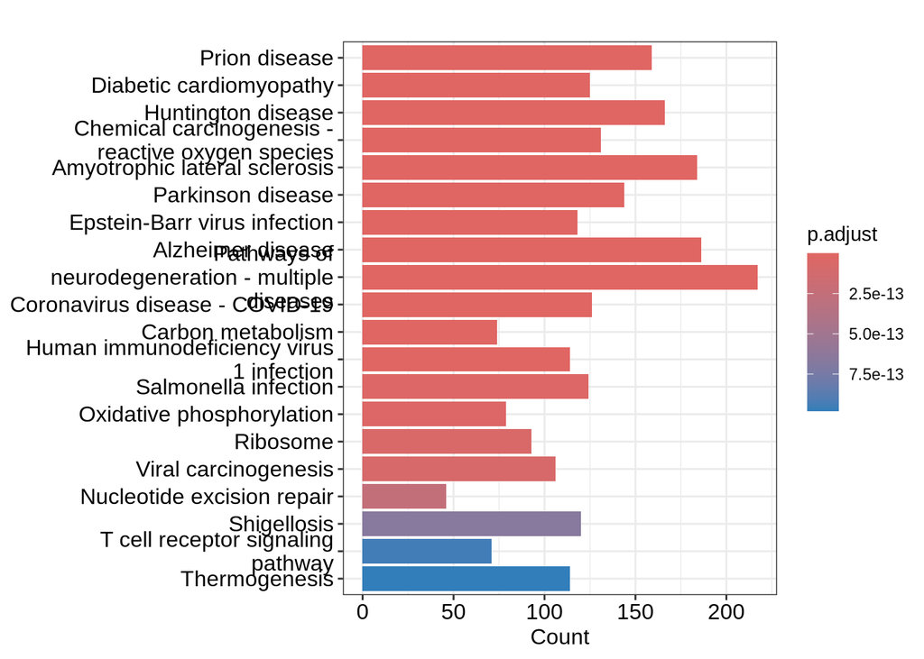

```r
barplot(pathway_enrichment, showCategory = 20)
```

Below the gene network displays which genes are involved in these significant terms. It also shows that a gene can belong to multiple pathways.

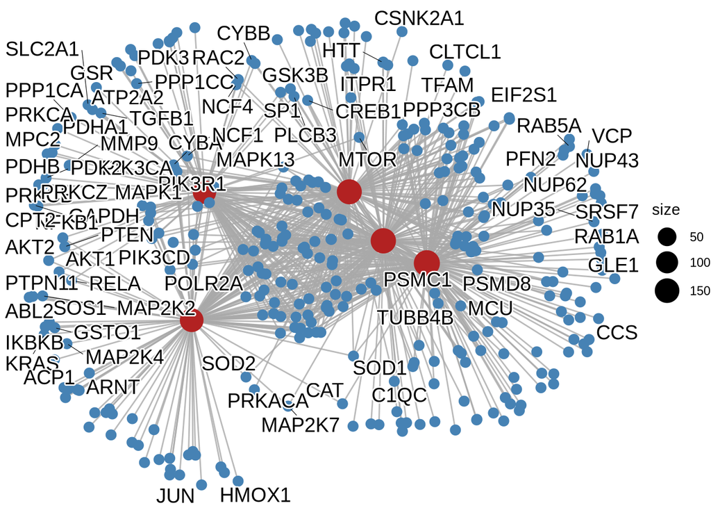

```r
pathway_enrichment_x <- setReadable(pathway_enrichment, 'org.Hs.eg.db', 'ENTREZID')
p <- cnetplot(pathway_enrichment_x, node_label="all", color_category='firebrick', color_gene='steelblue')
cowplot::plot_grid(p)
```

Furthermore, in the enrichment map shown below, enrichment pathways are linked by overlapping gene sets, from which the enrichment pathways like “Prion disease,” “Diabetic cardiomyopathy,” “Huntington disease,” “Parkinson disease” and “Human cytomegaglovirus infection” prominent the functional modules.

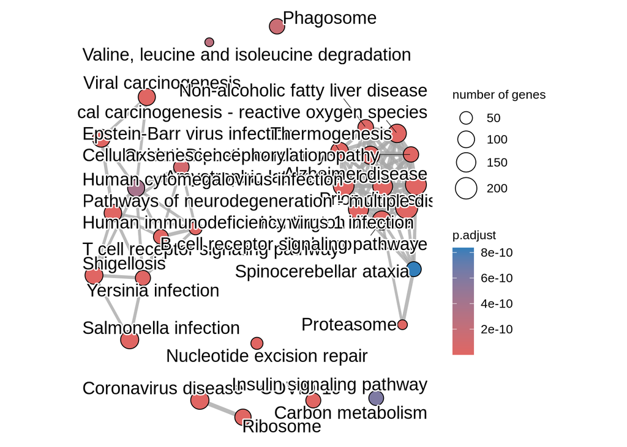

```r
pathway_enrichment_x2 <- pairwise_termsim(pathway_enrichment)
p1 <- emapplot(pathway_enrichment_x2)
cowplot::plot_grid(p1)
```

# 6 Extension and Discussion

From this output, it implies the potential pathways related to the clinical outcome, which greatly reduces the original large feature space, and could be used to predict the overall survival of the patients. For example, the most significant pathways corresponds to genes with Entrez IDs and UniProt IDs -

```r
selected_feature_Entrez_IDs <- pathway_enrichment@result$geneID[1:1000]
selected_feature_Entrez_IDs <- strsplit(selected_feature_Entrez_IDs, split = "/")
selected_feature_UniProt_IDs <- UniProt2Entrez$From[which(unlist(UniProt2Entrez$To) %in% unlist(selected_feature_Entrez_IDs))]

# selected_feature_Entrez_IDs
selected_feature_UniProt_IDs
```

```
#>    [1] "A0AVT1" "A1L188" "A2RTX5" "A5D8V6" "A5YKK6" "A6NDG6" "A6NHL2" "A8MXV4"
#>    [9] "B0I1T2" "B2RTY4" "I3L1I5" "O00115" "O00116" "O00139" "O00154" "O00159"
#>   [17] "O00160" "O00161" "O00170" "O00189" "O00194" "O00203" "O00213" "O00217"
#>   [25] "O00221" "O00231" "O00232" "O00233" "O00244" "O00255" "O00257" "O00264"
#>   [33] "O00267" "O00268" "O00273" "O00287" "O00291" "O00308" "O00329" "O00399"
#>   [41] "O00400" "O00410" "O00422" "O00429" "O00459" "O00462" "O00463" "O00471"
#>   [49] "O00472" "O00483" "O00487" "O00499" "O00505" "O00522" "O00555" "O00559"
#>   [57] "O00566" "O00567" "O00571" "O00629" "O00750" "O00754" "O00764" "O14492"
#>   [65] "O14497" "O14521" "O14548" "O14561" "O14617" "O14618" "O14639" "O14641"
#>   [73] "O14653" "O14662" "O14672" "O14686" "O14727" "O14733" "O14734" "O14735"
#>   [81] "O14745" "O14772" "O14773" "O14776" "O14787" "O14802" "O14818" "O14862"
#>   [89] "O14880" "O14920" "O14929" "O14949" "O14964" "O14974" "O14975" "O14980"
#>   [97] "O15020" "O15031" "O15042" "O15047" "O15056" "O15066" "O15067" "O15111"
#>  [105] "O15116" "O15117" "O15118" "O15121" "O15143" "O15144" "O15145" "O15151"
#>  [113] "O15155" "O15160" "O15173" "O15211" "O15228" "O15229" "O15230" "O15234"
```

[output cut: 272 more lines]

Following the previous prediction setting, these genes can be tested to see their predictive power -

```r
# X <- assay(se_imputed)[which(rowData(se)$protID %in% selected_feature_UniProt_IDs), ]

# ctrl2 <- rfeControl(functions = caretFuncs,
#                    method = "repeatedcv",
#                    repeats = 5,
#                    verbose = FALSE)

# selected_feature_survival_period <- rfe(t(X), annotation$survival_period,
#                  sizes = subsets,
#                  rfeControl = ctrl2,
#                  model = "enet")
```

```r
# selected_feature_survival_period
```

```r
# selected_feature_survival_period$fit
```

[^1]: Lazar, Cosmin, et al. “Accounting for the multiple natures of missing values in label-free quantitative proteomics data sets to compare imputation strategies.” Journal of proteome research 15.4 (2016): 1116-1125.
[^2]: VanderWeele, Tyler J. “Principles of confounder selection.” European journal of epidemiology 34 (2019): 211-219.